# Domestic Flight Delays Prediction: Airline Delays Data

# 1 Project Background

Flight delay has become a very important subject for air transportation all over the world because of the associated financial losses that the aviation industry experiences. These delays not only cause inconveniences to the passengers but also to the airlines. Due to the increased travel time, passengers are forced to spend more money on food and lodging, ultimately resulting in stress. Airlines face extra costs due to crew re-positioning, fuel consumption while trying to reduce elapsed times, and a variety of other factors that could potentially reduce their reputation and lower passenger demand. These delays can be attributed to a variety of factors, including air congestion, poor weather conditions, mechanical problems, difficulties boarding passengers, and simply the airline’s inability to handle the demand.

So, what can be done as a passenger to avoid delayed flights? Is it possible to know if your flight will be delayed before it comes up on the departure boards? Or perhaps, before you being inside the plane? The answer to these questions is maybe. By using Machine Learning (ML) Algorithms we can try to predict if a flight will be delayed in many ways.

# 2 About the Data

This is what the first 5 rows of our dataset looks like:

The first 5 rows of the dataset

| FL_DATE | OP_CARRIER | OP_CARRIER_FL_NUM | ORIGIN | DEST | CRS_DEP_TIME | DEP_TIME | DEP_DELAY | TAXI_OUT | WHEELS_OFF | WHEELS_ON | TAXI_IN | CRS_ARR_TIME | ARR_TIME | ARR_DELAY | CANCELLED | CANCELLATION_CODE | DIVERTED | CRS_ELAPSED_TIME | ACTUAL_ELAPSED_TIME | AIR_TIME | DISTANCE | CARRIER_DELAY | WEATHER_DELAY | NAS_DELAY | SECURITY_DELAY | LATE_AIRCRAFT_DELAY | Unnamed..27 |
| --- | --- | --- | --- | --- | --- | --- | --- | --- | --- | --- | --- | --- | --- | --- | --- | --- | --- | --- | --- | --- | --- | --- | --- | --- | --- | --- | --- |
| 2015-02-26 | US | 1812 | CLT | BOS | 2211 | 2233 | 22 | 16 | 2249 | 12 | 9 | 10 | 21 | 11 | 0 |  | 0 | 119 | 108 | 83 | 728 | NA | NA | NA | NA | NA | NA |
| 2015-08-10 | UA | 259 | GRR | ORD | 1805 | 1856 | 51 | 12 | 1908 | 1836 | 33 | 1810 | 1909 | 59 | 0 |  | 0 | 65 | 73 | 28 | 137 | 0 | 0 | 59 | 0 | 0 | NA |
| 2015-06-10 | WN | 746 | ONT | LAS | 1105 | 1106 | 1 | 23 | 1129 | 1209 | 6 | 1200 | 1215 | 15 | 0 |  | 0 | 55 | 69 | 40 | 197 | 0 | 0 | 15 | 0 | 0 | NA |
| 2015-01-06 | HA | 313 | HNL | LIH | 1201 | 1152 | -9 | 18 | 1210 | 1234 | 6 | 1240 | 1240 | 0 | 0 |  | 0 | 39 | 48 | 24 | 102 | NA | NA | NA | NA | NA | NA |
| 2015-09-28 | EV | 2609 | PNS | DFW | 1904 | 1858 | -6 | 12 | 1910 | 2040 | 15 | 2115 | 2055 | -20 | 0 |  | 0 | 131 | 117 | 90 | 604 | NA | NA | NA | NA | NA | NA |

This data now has 581908 rows.

## 2.1 SMART Questions

By using Statistical Modeling and Machine learning methods, we will attempt to predict if a flight is going to be delayed, based on features that are available prior to this information being displayed on the airport schedule boards.

Now we will begin our analysis.

# 3 Data Preprocessing and Initial Analysis

Glossary of all the columns in the dataset:

- FL_DATE = Date of the Flight
- OP_CARRIER = Airline Identifier
- OP_CARRIER_FL_NUM = Flight Number
- ORIGIN = Starting Airport Code
- DEST = Destination Airport Code
- CRS_DEP_TIME = Planned Departure Time
- DEP_TIME = Actual Departure Time
- DEP_DELAY = Total Delay on Departure in minutes
- TAXI_OUT = The time duration elapsed between departure from the origin airport gate and wheels off
- WHEELS_OFF = The time point that the aircraft’s wheels leave the ground
- WHEELS_ON = The time point that the aircraft’s wheels touch on the ground
- TAXI_IN = The time duration elapsed between wheels-on and gate arrival at the destination airport
- CRS_ARR_TIME = Planned arrival time
- ARR_TIME = Actual Arrival Time = ARRIVAL_TIME - SCHEDULED_ARRIVAL
- ARR_DELAY = Total Delay on Arrival in minutes
- CANCELLED = Flight Cancelled (1 = cancelled)
- CANCELLATION_CODE = Reason for Cancellation of flight: A - Airline/Carrier; B - Weather; C - National Air System; D - Security
- DIVERTED = Aircraft landed on different airport that the one scheduled
- CRS_ELAPSED_TIME = Planned time amount needed for the flight trip
- ACTUAL_ELAPSED_TIME = AIR_TIME+TAXI_IN+TAXI_OUT
- AIR_TIME = The time duration between wheels_off and wheels_on time
- DISTANCE = Distance between two airports
- CARRIER_DELAY = Delay caused by the airline in minutes
- WEATHER_DELAY = Delay caused by weather
- NAS_DELAY = Delay caused by air system
- SECURITY_DELAY = caused by security reasons
- LATE_AIRCRAFT_DELAY = Delay caused by security

*Source : [kaggle](https://www.kaggle.com/datasets/yuanyuwendymu/airline-delay-and-cancellation-data-2009-2018?select=2009.csv)*

Looking at this glossary was an extremely important step to map what features can be used and cannot be used.

## 3.1 Project Obejctive

We reinforce the primary objective of the project, which is to predict whether a flight is going to be delayed or not, **prior to this information being displayed on the departure board**. Therefore, to define delay, we will look at the column `ARR_DELAY`. If a flight arrives late at its destination, it will be considered as delayed. This is a numeric columns with the time difference in the arrival as minutes. Positive values indicate a delay, while a negative value indicates an early arrival. As first step, we will have a look at the distribution of these levels in the dataset as that is an important aspect while training our models.

There are 208619 rows with arrival delay and 362745 rows without delay.  
We can see that there are more flights that are not delayed than flights that are delayed. This might represent some imbalance in our dataset.

We’ll create a new binary variable `DELAYED_STATUS` to indicate whether a flight was delayed `1` or not delayed `0`.

From the glossary, we can also identify a few attributes that give a lot of information on whether a flight is going to be delayed. These columns are:

- Wheels On
- Taxi In
- Actual Elapsed Time

It may not be a good idea to include these attributes during model building as this information is available after the flight takes off from the source airport and is not logical to make use of to predict whether the flight is going to be delayed. To demonstrate this idea, we can build two models - one without these attributes and one with them. The model with these attributes will result in better accuracy, precision, and recall.

“Departure Delay” is not listed above, which may be considered a borderline variable known just as the flight departs from source. However, departure delay does not always indicate a delay in arrival. It could be the case that a flight has departure delay but airlines try to account for these delays by reducing their elapse time, and in some cases, they succeed and the planes end up arriving on time or even earlier.

We can see this with the graph below -

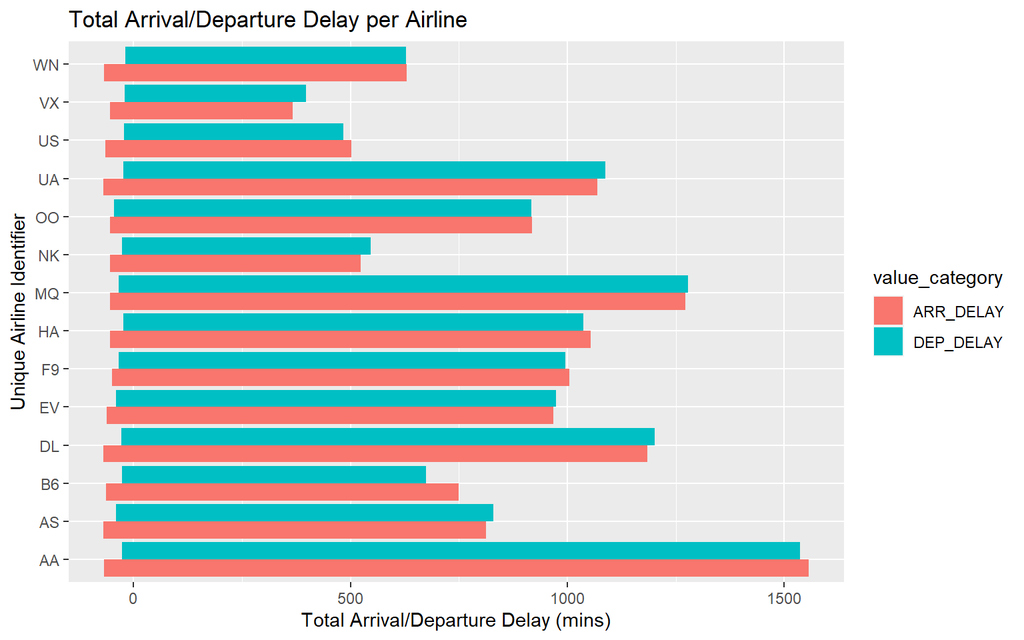

We get a rough idea that departure delays do not necessarily amount to an arrival delay with this plot, as some airlines can be seen to have total departure delays greater than their arrival delays.

Looking at the mean arrival/departure delays will reinforce the point further.

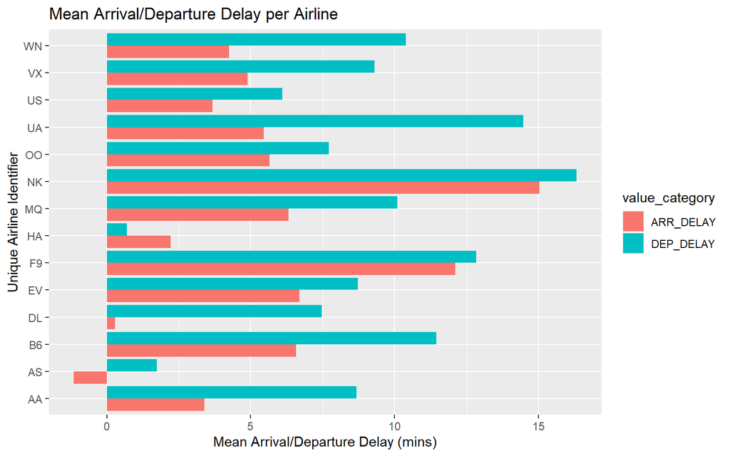

We can clearly see that airlines that are prone to high departure delays, do not necessarily need to have a high arrival delay as well.

Before we proceed further, we noticed the presence of a column called `Unnamed..27`, and most of the rows at first glance are nulls. We further look into this column to find all the null values.

Therefore, we can drop this column.

Before moving on, typing the column names in caps all the time is very exhausting. Therefore, we will further convert the column names to all lower cases.

Now the first 5 rows look like this.

The first 5 rows with lower case column names

| fl_date | op_carrier | op_carrier_fl_num | origin | dest | crs_dep_time | dep_time | dep_delay | taxi_out | wheels_off | wheels_on | taxi_in | crs_arr_time | arr_time | arr_delay | cancelled | cancellation_code | diverted | crs_elapsed_time | actual_elapsed_time | air_time | distance | carrier_delay | weather_delay | nas_delay | security_delay | late_aircraft_delay | delayed_status |
| --- | --- | --- | --- | --- | --- | --- | --- | --- | --- | --- | --- | --- | --- | --- | --- | --- | --- | --- | --- | --- | --- | --- | --- | --- | --- | --- | --- |
| 2015-02-26 | US | 1812 | CLT | BOS | 2211 | 2233 | 22 | 16 | 2249 | 12 | 9 | 10 | 21 | 11 | 0 |  | 0 | 119 | 108 | 83 | 728 | NA | NA | NA | NA | NA | 1 |
| 2015-08-10 | UA | 259 | GRR | ORD | 1805 | 1856 | 51 | 12 | 1908 | 1836 | 33 | 1810 | 1909 | 59 | 0 |  | 0 | 65 | 73 | 28 | 137 | 0 | 0 | 59 | 0 | 0 | 1 |
| 2015-06-10 | WN | 746 | ONT | LAS | 1105 | 1106 | 1 | 23 | 1129 | 1209 | 6 | 1200 | 1215 | 15 | 0 |  | 0 | 55 | 69 | 40 | 197 | 0 | 0 | 15 | 0 | 0 | 1 |
| 2015-01-06 | HA | 313 | HNL | LIH | 1201 | 1152 | -9 | 18 | 1210 | 1234 | 6 | 1240 | 1240 | 0 | 0 |  | 0 | 39 | 48 | 24 | 102 | NA | NA | NA | NA | NA | 0 |
| 2015-09-28 | EV | 2609 | PNS | DFW | 1904 | 1858 | -6 | 12 | 1910 | 2040 | 15 | 2115 | 2055 | -20 | 0 |  | 0 | 131 | 117 | 90 | 604 | NA | NA | NA | NA | NA | 0 |

We notice the presence of another feature in the dataset, that gives us information on flight cancellations - `cancelled`. However, flight_delay_status and cancellation cannot be used together at the same time. If a flight gets cancelled, then delay does not make sense and should not be applicable to our prediction. Let’s make sure that this is the case. If a flight is marked as `cancelled` = 1, then arrival delay and departure delay should be null values.

Upon checking, we see that our assumption stands. For flights that were cancelled, arrival delay is always null. So to build a model that predicts whether a flight is delayed, we cannot use the data for when flights were cancelled as we will get erroneous results. Therefore, we will subset our dataset for only `cancelled` = 0.

In addition to this, there’s another column which is called the `cancellation_code` which explains the cancellation reason for these cancelled flights. Since, we’ve already subset to `cancelled` = 0, we expect to see nulls in this column as there needn’t be a cancellation reason any longer. We proceed to verify this with coding.

We verify that we see all values in `cancellation_code` are now null or blank values. Therefore, we can remove this column from the dataset.

Another variable that catches attention is `diverted`. A diverted flight is one that has landed in a different airport than the one scheduled. This is normally temporary and the airline has the responsibility of taking passengers to their final destination without any extra cost. Therefore this is ideally considered a delayed flight.

This column contains only 2 values, 0 and 1. The 1’s are extremely small in occurrence. The assumption here is that 1 indicates that a flight has been diverted. A diverted flight should have the `arr_delay` column populated, as it should definitely have delay on arrival to the actual destination airport. We proceed to confirm this with code.

The results are inconsistent with the assumption. As it turns out, all diverted flights have no information on the `arr_delay`. This renders this column useless to us for predicting delay. Therefore, we will be removing this column as well.

Now turning our attention to the the columns that cite the delay reason. On first glance, majority of the observations contain null values which is not a good sign. We try to get a count of how many null values there are.

We find that around 81.5% of all our observations contain null values for these columns and for some reason, the information is missing from columns at all the same instances. The conclusion is that we cannot use this column for any useful predictions owing to the large missing values. The choice is to drop these columns too. However, before doing that, we’ll make a copy of flight dataset, maybe we can perform interesting EDA using this column using available rows (finding out the top reason for delay).

## 3.2 Checking for further missing values in the dataset

We see that quite a few columns still have null values. However, the proportion of these values is extremely small as compared to the size of the dataset. We will go ahead and remove these rows to ensure model is built correctly.

Checking the distribution of `delayed_status` column again.

```
##
##      0      1
## 362745 208619
```

We still have enough 0’s and 1’s to build a logistic regression model.

Now, for EDA purposes, we will make use of the external files airlines and airports to get respective airline names and city/state names into the dataset.

First getting the airline names.

Next, getting the city name and state name into the dataset.

We can drop the original columns because it is redundant information.

This is what the first 5 rows look like now:

The first 5 rows of the dataset

| fl_date | op_carrier_fl_num | origin | dest | crs_dep_time | dep_time | dep_delay | taxi_out | wheels_off | wheels_on | taxi_in | crs_arr_time | arr_time | arr_delay | crs_elapsed_time | actual_elapsed_time | air_time | distance | delayed_status | airline | city_orig | city_dest | state_orig | state_dest |
| --- | --- | --- | --- | --- | --- | --- | --- | --- | --- | --- | --- | --- | --- | --- | --- | --- | --- | --- | --- | --- | --- | --- | --- |
| 2015-02-26 | 1812 | CLT | BOS | 2211 | 2233 | 22 | 16 | 2249 | 12 | 9 | 10 | 21 | 11 | 119 | 108 | 83 | 728 | 1 | US Airways Inc. | Charlotte | Boston | NC | MA |
| 2015-08-10 | 259 | GRR | ORD | 1805 | 1856 | 51 | 12 | 1908 | 1836 | 33 | 1810 | 1909 | 59 | 65 | 73 | 28 | 137 | 1 | United Air Lines Inc. | Grand Rapids | Chicago | MI | IL |
| 2015-06-10 | 746 | ONT | LAS | 1105 | 1106 | 1 | 23 | 1129 | 1209 | 6 | 1200 | 1215 | 15 | 55 | 69 | 40 | 197 | 1 | Southwest Airlines Co. | Ontario | Las Vegas | CA | NV |
| 2015-01-06 | 313 | HNL | LIH | 1201 | 1152 | -9 | 18 | 1210 | 1234 | 6 | 1240 | 1240 | 0 | 39 | 48 | 24 | 102 | 0 | Hawaiian Airlines Inc. | Honolulu | Lihue | HI | HI |
| 2015-09-28 | 2609 | PNS | DFW | 1904 | 1858 | -6 | 12 | 1910 | 2040 | 15 | 2115 | 2055 | -20 | 131 | 117 | 90 | 604 | 0 | Atlantic Southeast Airlines | Pensacola | Dallas-Fort Worth | FL | TX |

Now to answer one of the SMART questions, since there is slight skewness between the predicted variable, accuracy will not be enough as a criteria to judge our model. Precision and recall will play an important role as well. However, as the business problem is predicting whether a flight is delayed or not, it is more important to catch all flights that are actually delayed as opposed to optimizing whether a predicted delay is correct or not. There is no harm in proactively anticipating and preparing for flights that have anticipated delayed and they turn out to be not delayed. However, there is greater business loss if we miss out on flights that are delayed but we were not able to identify them.

In technical terms, our models need to be tuned to have a higher **recall** as opposed to **precision**.

## 3.3 Feature Engineering and EDA

We can also make a month and a day variable, which could be good predictors of delays. Additionally, creating a day of the week variable starting with Sunday. We do this from the date column that is already present in the dataset.

We can also extract the hour of the scheduled flight to see if time of day is a good predictor.

Lets first answer some questions on airline quality in terms of delays through some EDA.

Plotting the graph of Number of Flights by Airline:

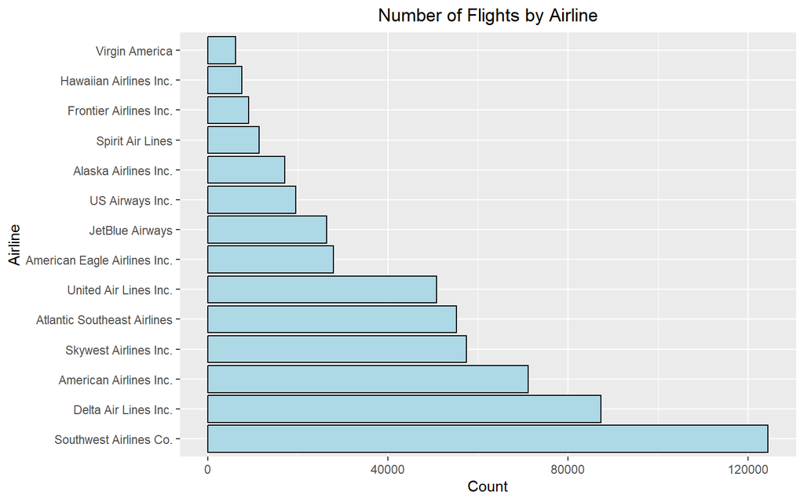

This is quite an interesting plot to start with as it already tells us which are the airlines that have the most domestic flights in the US:

1. Southwest Airlines
2. Delta Airlines
3. American Airlines
4. SkyWest Airlines
5. Atlantic South East Airlines

Now the question to ask ourselves would be: if the top 5 airlines in terms of number of flight, are also the best in terms of arriving on time? We’ll see which are the airlines with the most delayed flight to try to answer this:

Graphing Number of Flight Delays by Airlines.

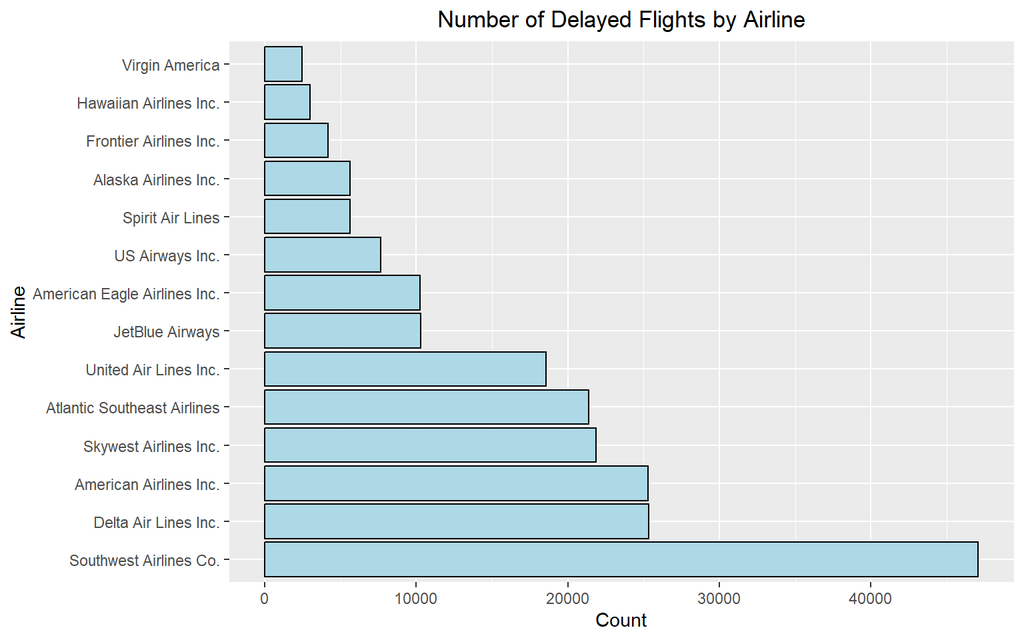

From this plot we can now extract the top 5 airlines with the most delayed flights, which are:

1. Southwest Airlines
2. Delta Airlines
3. American Airlines
4. SkyWest Airlines
5. Atlantic SouthEast Airlines

It appears as if the Airlines with the most number of flights, tend to have more number of delayed flights as well.

However, this may not be the best way to judge the performance of an airlines. To do so, we will calculate the percentage of delayed flights and the average delay time per airline, as that might be a better representation of how the airlines really perform.

The first thing to calculate is the overall percentage of delayed flights so that we can do proper comparisons with each airline. In other words, airlines would want to be below the average percentage of delayed flights to be in an acceptable position, so this mean number will represent our threshold. Airlines above would be by common sense the ones that travelers would want to avoid as it means you those will have the most delays.

From analysis, we found this threshold to be 0.3651. This goes to say that 36.51% of the flights are delayed, roughly 1 out of every 3 flight was delayed in the year 2015.

After performing some extra manipulation, we can plot the percentage of flight delays per airline, also showcasing the threshold value that is calculated from the data. This should give us a good indicator of which airline performs well.

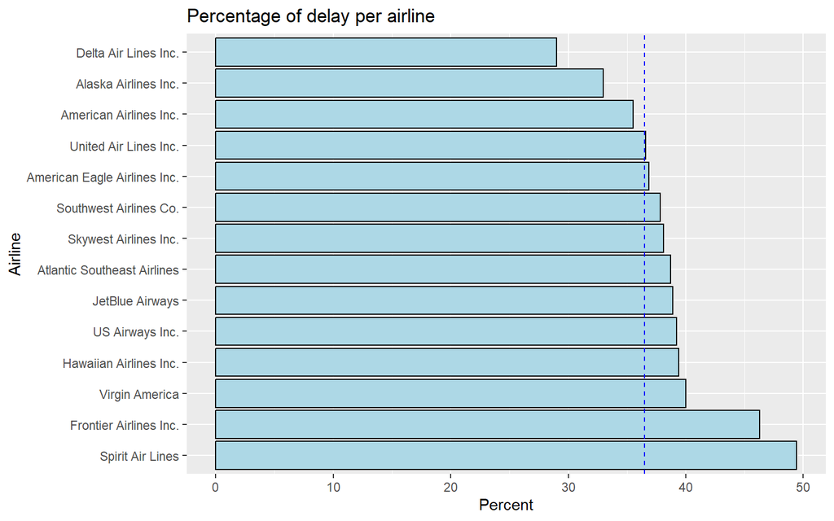

This is provides us with really interesting observations.

Delta Airlines is the second airline with the highest number of flights, at the same time is again the second highest number of delayed flights, but in terms of percentage of delayed flights, it is the airline with the best percentage at 29.02%. That represents ~7% below the threshold.

American Airlines in another airline that tops the list in terms of number of flights but is still below the threshold value in terms of delay. So these two airlines must be the most sought after by passengers if they want to avoid delay.

Southwest Airlines has the most flights and consequently, a higher number of delayed flights as well, but as our last plot suggests, it is not the worst, it is the sixth best and is above the threshold value by over 1%, so definitely not great compared to Delta Airlines.  
Similarly Atlantic SouthEast Airlines and United airlines have large number of flights but perform somewhat moderately when compared to other airlines.

Now coming to the bad airlines. The top 4 airlines with the highest percent of delays happen to be the top 4 airlines with the least number of flights as well. These airlines should definitely be avoided by passengers if they want to ensure timely arrival.

Further airline testing. Plotting total number of delay in minutes by each airline.

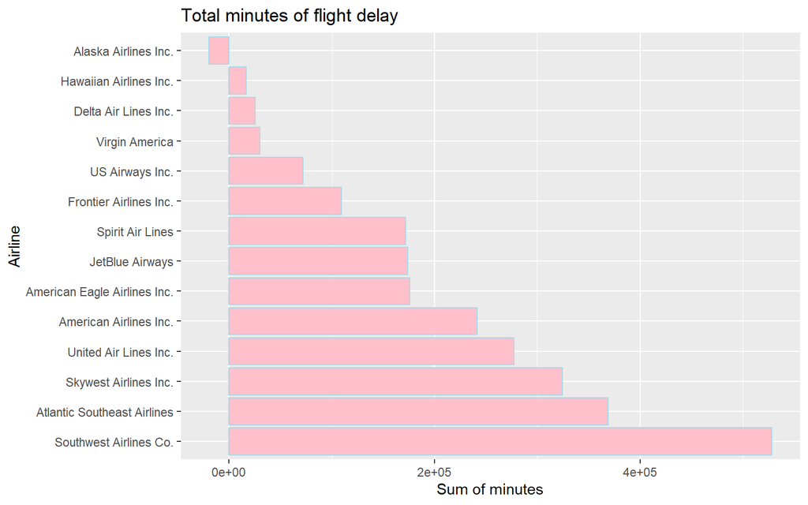

Another airline that comes into notice with this plot is the Alaska Airlines. The negative bar plot indicates that they are prone to actually arriving earlier than usual by a larger margin than their flights get delayed! Which is good news for the passengers, well, most of the times.

Verdict: Airlines to travel by - Delta Airlines, Alaska Airlines.

Next we plot the worst and best months to travel based on Flight delays.

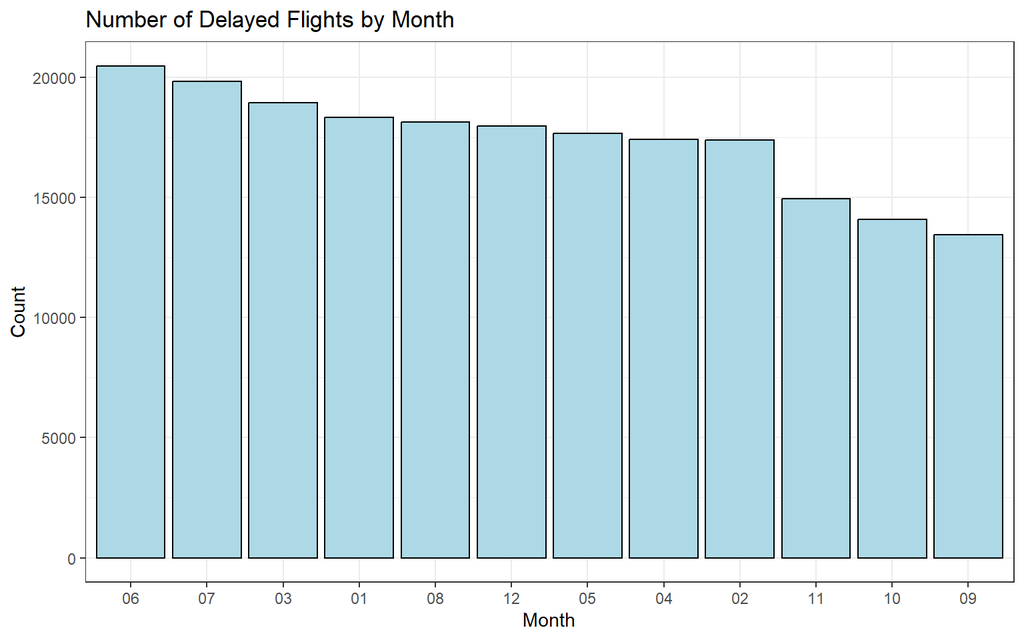

Seems like the best month to travel is September with the least number of Delays, whereas June consists of a lot of delays.

However, this is just an absolute number. A better way to find the best and worst months to travel will be through proportions. Lets first plot the count of flights that run in each month.

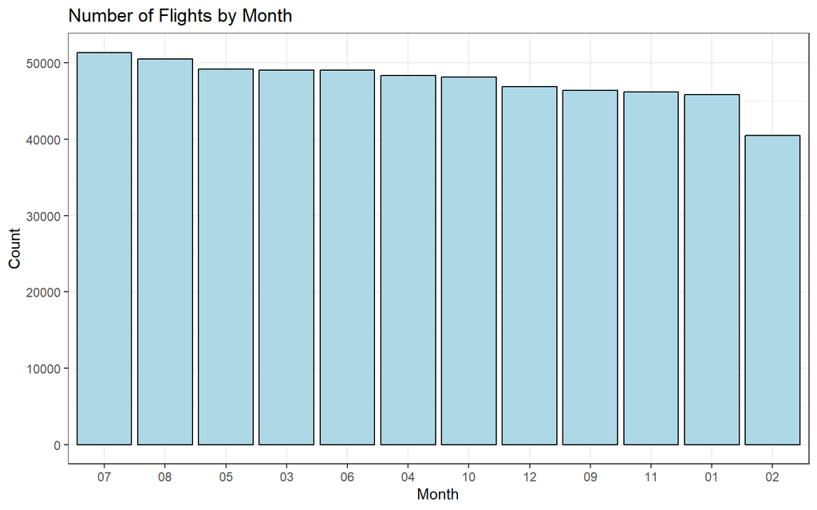

Looks like the busiest months are July, August and May. One possible explanation is start and end of summer vacations??

Now lets plot the proportion. Graph of percent of flight delays by month

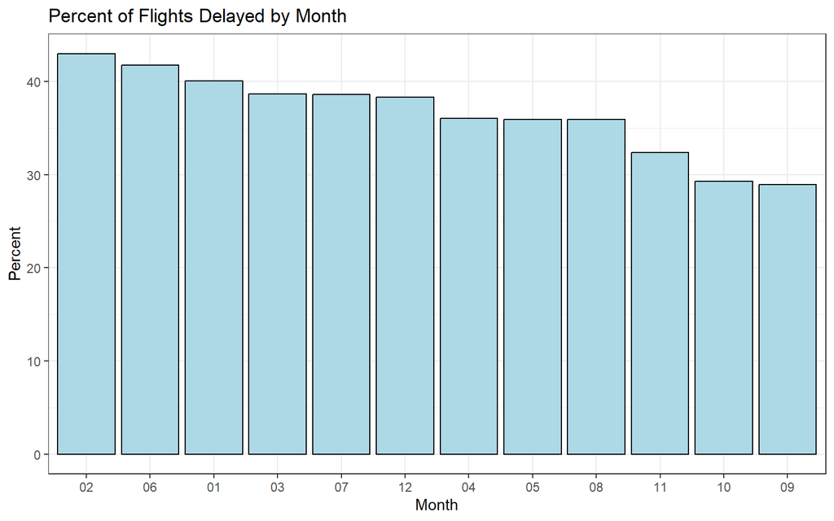

Seems like September runs the least number of delayed flights being the 9th busiest month and has the lowest proportion of delay. October, too is the 7th busiest month and 2nd least delay month. Seems like airline companies really buckle up on delays in these months whereas maintaining a moderately high number of flights.

January runs the 2nd least number of flights with the 4th highest delays. Must be stressful for the few passengers that travel then.

March and July run a large number of flights with a large number of delays.

We’ll repeat the same exercise for day of the week. Graphing Number of Flight Delays by Day Of Week

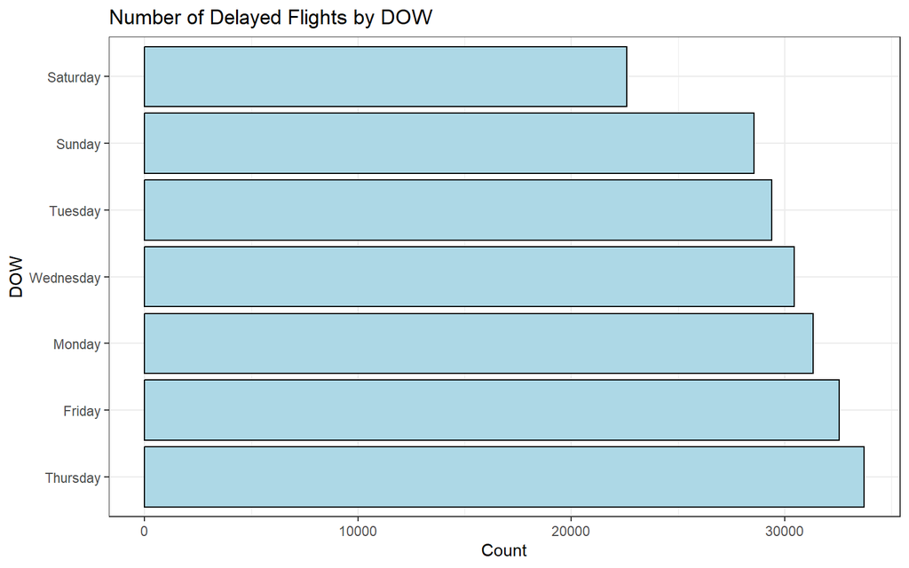

Now plotting the total number of flights in the week.

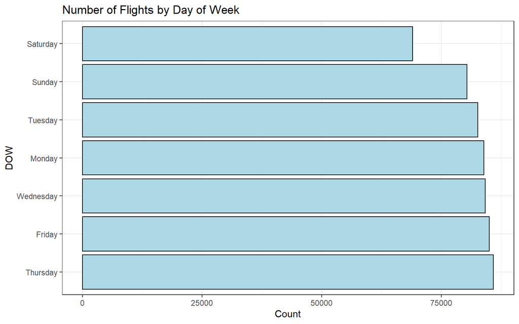

Seems like the busiest days are Friday and Thursday and a result, they also have the most delayed number of flights. Whereas, Saturday and Sunday are least busiest with lesser number of delays.

Plotting graph for percent of flight delays by Day of Week.

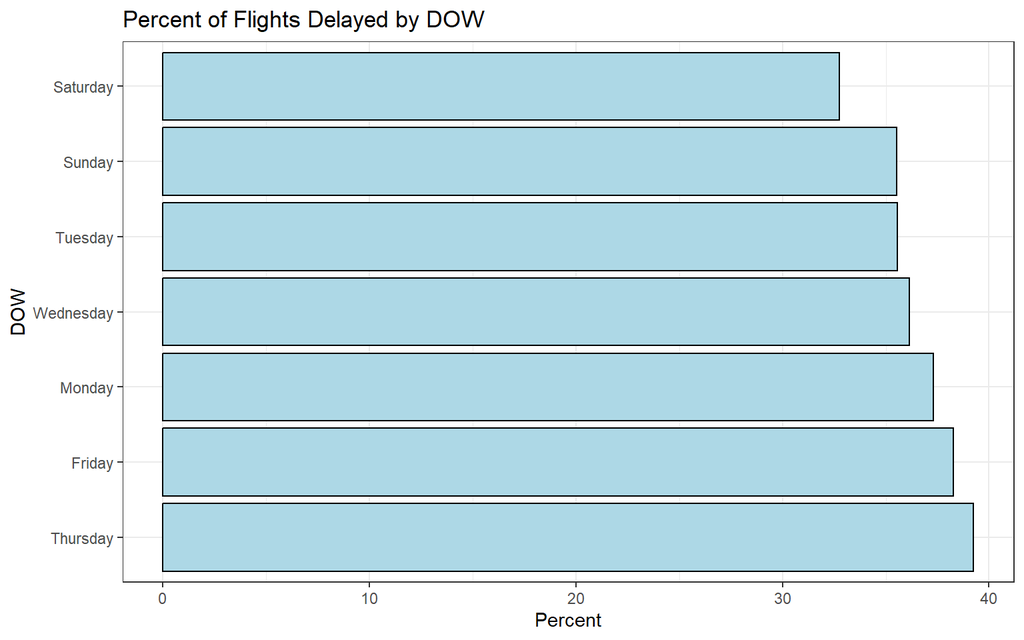

Now lets try to see the top 20 most popular cities and how their average arrival delay looks like.

Lets look at the 20 most popular destination cities in the US first.

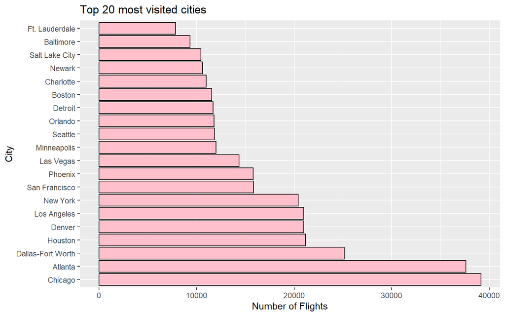

Now lets add another axis and look at the average delay in the top 20 destinations.

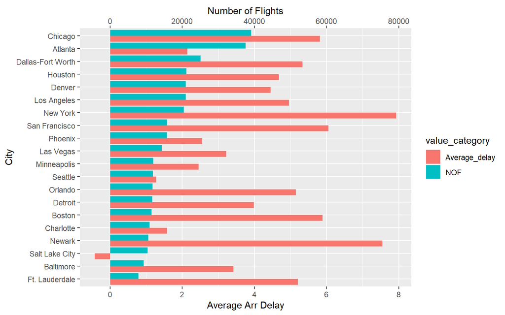

This graph gives us lots of useful information about the top 20 most visited cities. It is interesting to see how Atlanta, having such a high number of landings, has a very low average delay with just over 2 minutes, whereas Newark, a not so popular destination, has such a high minute average delay. New York, which is the 7th most popular destination (not sure why this is the case since its so popular) has the highest average delay out of all, which doesn’t add up with it being the 7th most visited place. San Francisco is another destination that stands out with a high average delay as well as Orlando and Boston.

Fun Fact - Salt Lake City is famous for its early arriving flight. We should probably go and visit.

Now we’ll repeat the same analysis for top 20 origin cities and associated departure delays with them.

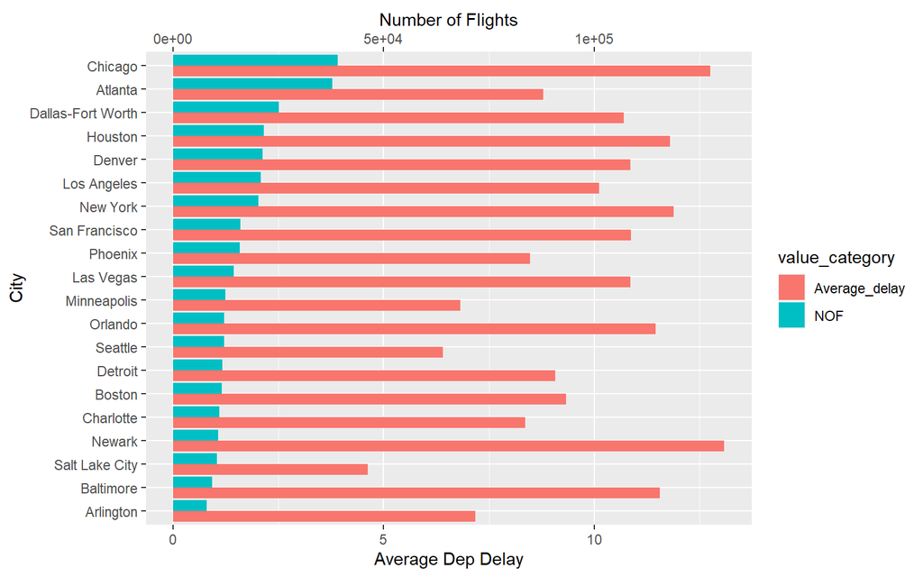

For the last EDA, lets also plot the number of destinations by Airlines to see which airline has the maximum ‘coverage’.

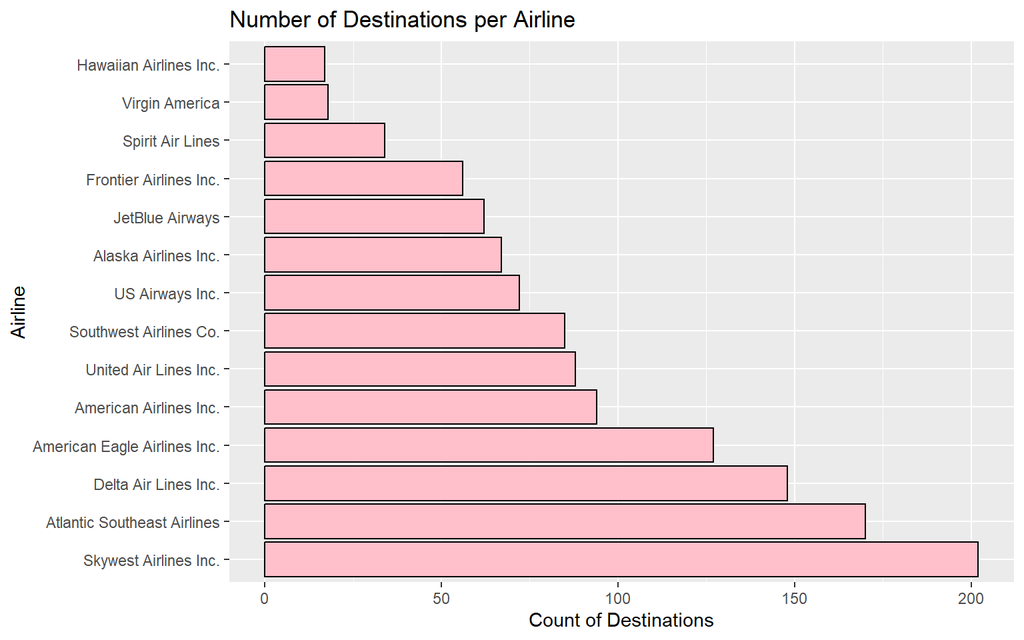

Delta Air Lines has once again managed to appear in top 3, providing with the 3rd highest coverage. Its a no brainer at this point to use this airline for domestic travel in the US.

# 4 ML Modeling

## 4.1 Logistic Regression

Having over 500,000 is too much to process in the model and is causing the session to slow down. To prevent this, we are going to further subset the dataset before processing and also store certain features as factor variables.

We will include the following variables in our initial development of our model to predict delayed status: * Airline * Origin Airport * Destination Airport * Month * Day of Week * Time of Day (by hour of departure) * Distance

Performing a 4:1 Train-test Split of Dataset. Then we go ahead and build the logistic regression model first.

The following coefficients are significant:

```
##                                    Estimate Pr...z..
## (Intercept)                         -4.2650 1.65e-03
## airlineAtlantic Southeast Airlines   0.4264 1.90e-03
## airlineFrontier Airlines Inc.        0.6956 2.84e-05
## airlineHawaiian Airlines Inc.        0.9542 1.04e-03
## airlineJetBlue Airways               0.4359 3.01e-03
## airlineSkywest Airlines Inc.         0.5766 1.02e-05
## airlineSouthwest Airlines Co.        0.4674 1.65e-04
## airlineSpirit Air Lines              0.8018 6.35e-07
## airlineVirgin America                0.6223 6.99e-04
## originDHN                            3.0847 2.72e-02
## originDRO                            2.5555 2.89e-02
## originISN                            2.1976 4.35e-02
## originLRD                            2.2347 3.93e-02
## originMGM                            2.6300 1.33e-02
## originSGU                            2.9412 1.03e-02
## destAGS                              2.7435 3.63e-02
## destCOS                              2.4227 3.43e-02
## destGSO                              2.3179 4.63e-02
## destGSP                              2.3925 3.99e-02
## destILM                              2.9902 1.94e-02
## destMFR                              2.7964 4.05e-02
## destMOB                              2.3943 4.65e-02
## destSPS                              3.3169 3.41e-02
## destSRQ                              2.3943 4.80e-02
## MONTH02                              0.1483 4.32e-02
## MONTH04                             -0.1522 3.32e-02
## MONTH06                              0.1605 2.22e-02
## MONTH09                             -0.5159 4.66e-12
## MONTH10                             -0.5091 4.51e-12
## MONTH11                             -0.2604 3.48e-04
## dow.Q                               -0.1833 3.94e-06
## dow.C                               -0.1083 5.10e-03
## dow^4                               -0.1577 2.66e-05
## hour                                 0.0629 8.08e-91
```

Hour was also a significant predictor.

Let’s plot the ROC for this model used on our training set first.

```
## Area under the curve: 0.654
```

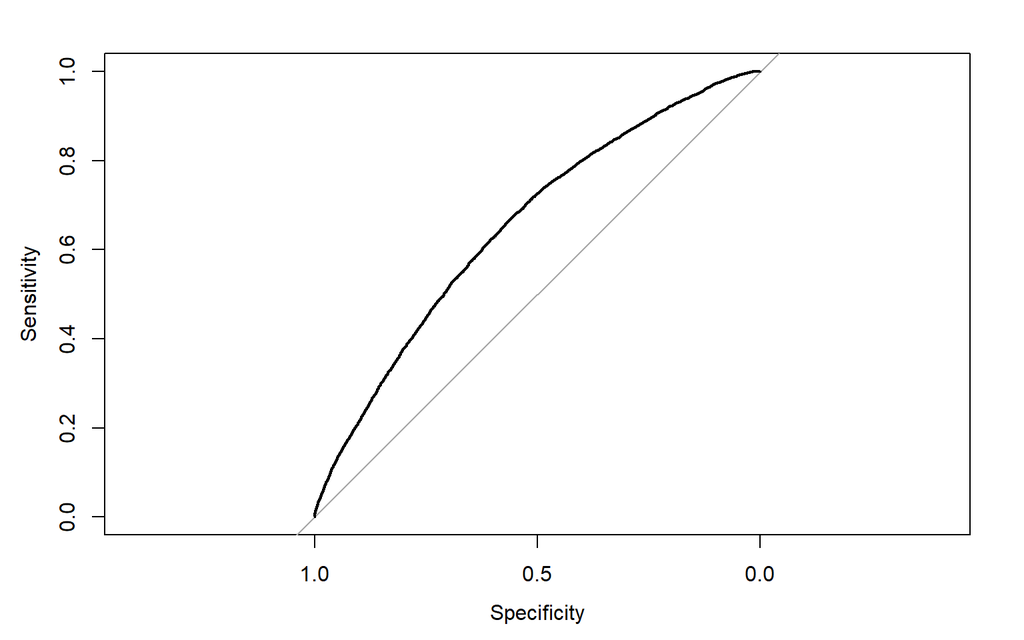

Next we’ll plot the ROC curve for our testing set.

```
## Area under the curve: 0.6
```

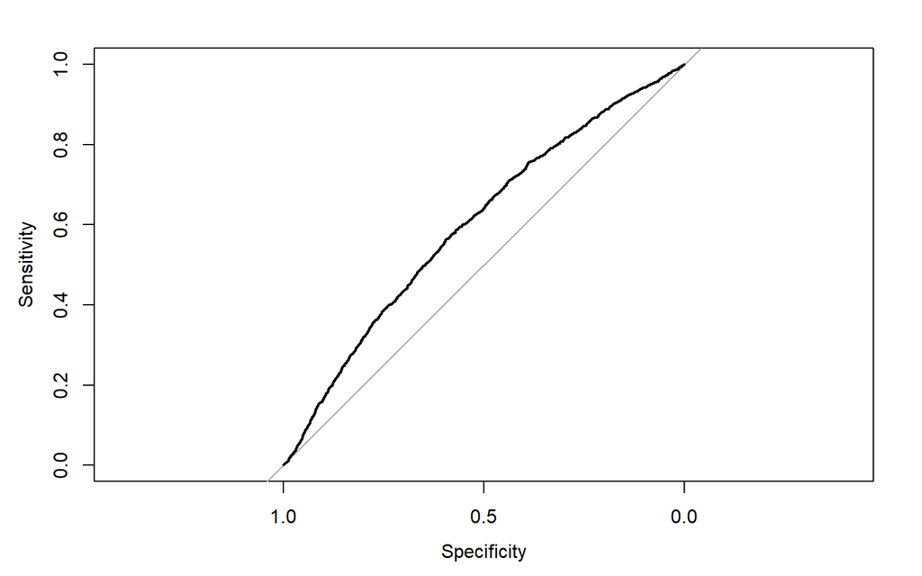

Area under the curve is 0.6543 on the training data, and 0.60 on the testing data.

Lets look at other model metrics.

```
## fitting null model for pseudo-r2
```

```
##       llh   llhNull        G2  McFadden      r2ML      r2CU
## -1.41e+04 -1.49e+04  1.67e+03  5.58e-02  7.06e-02  9.66e-02
```

Confusion Matrix:

```
## Confusion Matrix and Statistics
##
##           Reference
## Prediction    0    1
##          0 3240 1732
##          1  418  409
##
##                Accuracy : 0.629
##                  95% CI : (0.617, 0.642)
##     No Information Rate : 0.631
##     P-Value [Acc > NIR] : 0.602
##
##                   Kappa : 0.088
##
##  Mcnemar's Test P-Value : <2e-16
##
##             Sensitivity : 0.886
##             Specificity : 0.191
##          Pos Pred Value : 0.652
##          Neg Pred Value : 0.495
##              Prevalence : 0.631
##          Detection Rate : 0.559
##    Detection Prevalence : 0.857
##       Balanced Accuracy : 0.538
##
##        'Positive' Class : 0
##
```

Accuracy on model: 62.9% Sensitivity / Recall: 19.1% - 409 / (1731+409) Specificity: 88.57% Precision: 49.5%

The specificity on this model is pretty good, but the other metric could use some improvement. Let’s try with a different cutoff value of 0.4.

```
## Confusion Matrix and Statistics
##
##           Reference
## Prediction    0    1
##          0 2494 1166
##          1 1164  975
##
##                Accuracy : 0.598
##                  95% CI : (0.585, 0.611)
##     No Information Rate : 0.631
##     P-Value [Acc > NIR] : 1.000
##
##                   Kappa : 0.137
##
##  Mcnemar's Test P-Value : 0.983
##
##             Sensitivity : 0.682
##             Specificity : 0.455
##          Pos Pred Value : 0.681
##          Neg Pred Value : 0.456
##              Prevalence : 0.631
##          Detection Rate : 0.430
##    Detection Prevalence : 0.631
##       Balanced Accuracy : 0.569
##
##        'Positive' Class : 0
##
```

At a lower cutoff value, the accuracy is slightly lower at 59.8% but there is an improvement in the sensitivity of the model at 45.5%

Can go even further with a lower cutoff value of 0.3.

```
## Confusion Matrix and Statistics
##
##           Reference
## Prediction    0    1
##          0 1320  494
##          1 2338 1647
##
##                Accuracy : 0.512
##                  95% CI : (0.499, 0.525)
##     No Information Rate : 0.631
##     P-Value [Acc > NIR] : 1
##
##                   Kappa : 0.11
##
##  Mcnemar's Test P-Value : <2e-16
##
##             Sensitivity : 0.361
##             Specificity : 0.769
##          Pos Pred Value : 0.728
##          Neg Pred Value : 0.413
##              Prevalence : 0.631
##          Detection Rate : 0.228
##    Detection Prevalence : 0.313
##       Balanced Accuracy : 0.565
##
##        'Positive' Class : 0
##
```

Recall with this model is **76.9%**.

### 4.1.1 Trying with other variables

In this section, we’ll build this model again, but now we include those extra variables that help predict delay even better because they are known after the flight either departs from the origin airport or arrives at the destination airport, dropping the value addition of this prediction. But just to see how the prediction power increases.

Significant Coefficients:

```
##                        (Intercept)      airlineAmerican Airlines Inc.
##                           3.25e-08                           4.98e-02
## airlineAtlantic Southeast Airlines        airlineDelta Air Lines Inc.
##                           3.35e-02                           9.05e-03
##      airlineFrontier Airlines Inc.      airlineHawaiian Airlines Inc.
##                           6.05e-08                           1.72e-02
##             airlineJetBlue Airways       airlineSkywest Airlines Inc.
##                           2.85e-09                           2.23e-02
##      airlineSouthwest Airlines Co.            airlineSpirit Air Lines
##                           8.15e-16                           2.91e-11
##       airlineUnited Air Lines Inc.              airlineVirgin America
##                           4.58e-04                           1.41e-09
##                          originABI                          originABQ
##                           1.04e-03                           9.67e-04
##                          originACV                          originADQ
##                           2.09e-02                           1.23e-02
##                          originAEX                          originAGS
##                           2.01e-02                           4.36e-02
##                          originAMA                          originANC
##                           3.73e-02                           5.16e-06
##                          originASE                          originAUS
##                           2.40e-02                           3.97e-02
##                          originBET                          originBIL
##                           6.14e-04                           2.50e-02
##                          originBMI                          originBOI
##                           4.49e-02                           7.35e-03
##                          originBRD                          originBTR
##                           1.32e-02                           3.10e-03
##                          originBUR                          originBZN
##                           7.21e-04                           3.43e-03
##                          originCID                          originCOS
##                           4.76e-02                           5.99e-03
##                          originCRP                          originDAL
##                           6.54e-03                           6.78e-03
##                          originDEN                          originDFW
##                           3.01e-03                           8.19e-03
##                          originDHN                          originDLH
##                           3.27e-03                           3.16e-02
##                          originDRO                          originDSM
##                           1.47e-03                           1.70e-02
```

[output cut: 81 more lines]

```
##                           3.81e-03                           4.44e-02
##                          originTUS                          originXNA
##                           3.17e-03                           5.80e-03
##                          originYUM                            MONTH06
##                           2.44e-02                           2.96e-05
##                            MONTH07                            MONTH09
##                           2.67e-02                           4.05e-05
##                            MONTH10                            MONTH11
##                           3.03e-06                           1.67e-02
##                              dow.Q                              dow^4
##                           4.45e-03                           1.77e-05
##                               hour                           distance
##                           2.21e-90                           0.00e+00
##                actual_elapsed_time
##                           0.00e+00
```

McFadden:

```
## fitting null model for pseudo-r2
```

```
##       llh   llhNull        G2  McFadden      r2ML      r2CU
## -1.19e+04 -1.49e+04  6.16e+03  2.06e-01  2.37e-01  3.25e-01
```

Mc Fadden is 0.206

Plotting ROC.

```
## Area under the curve: 0.786
```

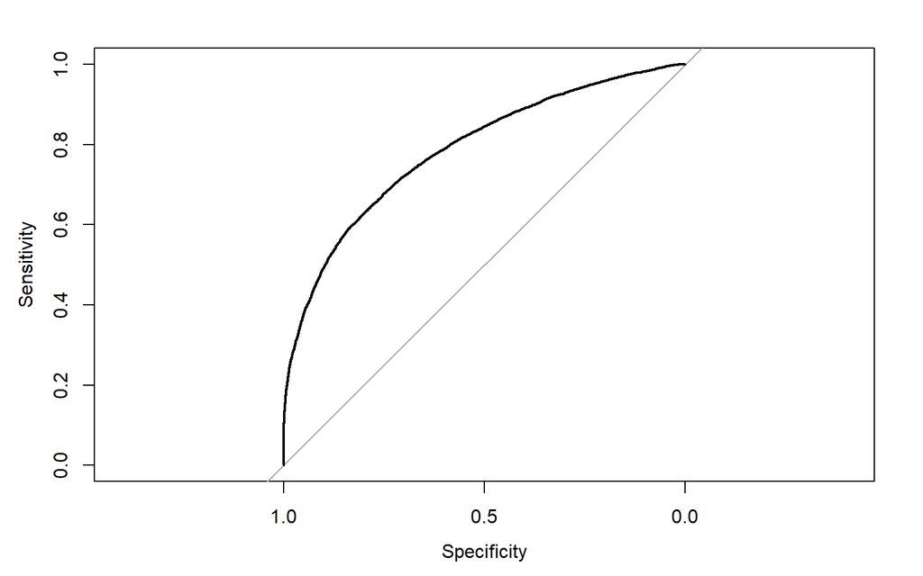

Confusion Matrix:

```
## Confusion Matrix and Statistics
##
##           Reference
## Prediction     0     1
##          0 12758  3957
##          1  1694  4353
##
##                Accuracy : 0.752
##                  95% CI : (0.746, 0.757)
##     No Information Rate : 0.635
##     P-Value [Acc > NIR] : <2e-16
##
##                   Kappa : 0.432
##
##  Mcnemar's Test P-Value : <2e-16
##
##             Sensitivity : 0.883
##             Specificity : 0.524
##          Pos Pred Value : 0.763
##          Neg Pred Value : 0.720
##              Prevalence : 0.635
##          Detection Rate : 0.560
##    Detection Prevalence : 0.734
##       Balanced Accuracy : 0.703
##
##        'Positive' Class : 0
##
```

## 4.2 Random Forest

Train-test splitting of 4:1 ratio again.

Unable to use factor variables that are more than 53 categories, so we have to drop origin and destination airports

Building Model.

Making Confusion Matrix:

For the training set-

```
## Confusion Matrix and Statistics
##
##           Reference
## Prediction    0    1
##          0 2884    5
##          1    0 1692
##
##                Accuracy : 0.999
##                  95% CI : (0.997, 1)
##     No Information Rate : 0.63
##     P-Value [Acc > NIR] : <2e-16
##
##                   Kappa : 0.998
##
##  Mcnemar's Test P-Value : 0.0736
##
##             Sensitivity : 1.000
##             Specificity : 0.997
##          Pos Pred Value : 0.998
##          Neg Pred Value : 1.000
##              Prevalence : 0.630
##          Detection Rate : 0.630
##    Detection Prevalence : 0.631
##       Balanced Accuracy : 0.999
##
##        'Positive' Class : 0
##
```

99.9% Accuracy on the training set

Confusion Matrix for the Testing set

```
## Confusion Matrix and Statistics
##
##           Reference
## Prediction   0   1
##          0 543 297
##          1 181 112
##
##                Accuracy : 0.578
##                  95% CI : (0.549, 0.607)
##     No Information Rate : 0.639
##     P-Value [Acc > NIR] : 1
##
##                   Kappa : 0.025
##
##  Mcnemar's Test P-Value : 1.44e-07
##
##             Sensitivity : 0.750
##             Specificity : 0.274
##          Pos Pred Value : 0.646
##          Neg Pred Value : 0.382
##              Prevalence : 0.639
##          Detection Rate : 0.479
##    Detection Prevalence : 0.741
##       Balanced Accuracy : 0.512
##
##        'Positive' Class : 0
##
```

Accuracy: 57.8% Sensitivity / Recall: 27.4% Specificity: 75.0% Precision: 38.2%

Again, specificity is good but the other measures are not.

Trying with different amounts of trees.

```
## Confusion Matrix and Statistics
##
##           Reference
## Prediction   0   1
##          0 543 297
##          1 181 112
##
##                Accuracy : 0.578
##                  95% CI : (0.549, 0.607)
##     No Information Rate : 0.639
##     P-Value [Acc > NIR] : 1
##
##                   Kappa : 0.025
##
##  Mcnemar's Test P-Value : 1.44e-07
##
##             Sensitivity : 0.750
##             Specificity : 0.274
##          Pos Pred Value : 0.646
##          Neg Pred Value : 0.382
##              Prevalence : 0.639
##          Detection Rate : 0.479
##    Detection Prevalence : 0.741
##       Balanced Accuracy : 0.512
##
##        'Positive' Class : 0
##
```

Playing around with maxnodes, number of trees, and tree depth doesn’t seem to improve the model very well

## 4.3 Notes on Data Limitations

We would have been able to significantly improve the quality of our models if we had the following additional data:

- Weather Data
- Airline Staffing Data
- Data on International Flights
- Airport Security Data

We might need to wait for more data, and higher computational power, before we can predict a brave new world for air travel - one without long queues and outrageous wait times, without airport sleepovers and missed schedules.

# 5 Summary and Conclusions

In summary, the key lessons learnt from the dataset used in this project and key analysis performed were:

- Certain Airlines and Airports are more likely to have delays than others.
- As the day progresses, delays are more likely to occur.
- The average delay percentage of domestic flights have dropped from 36.51% in 2015 to 20.19% in 2022 (YTD).
- Flight delays are difficult to predict! Combining with more data would have been helpful.
- While more dataset would have provided more insight, higher computational power is required to develop better models!

# 6 References

1. Flight Delays and Cancellation Dataset. US Department of Transportation’s (DOT) Bureau of Transportation Statistics (2015). Retrieved November 22, 2022, from https://www.kaggle.com/datasets/usdot/flight-delays
2. Zieffler, Andrew (2018). R Markdown Theme Gallery, from https://www.datadreaming.org/post/r-markdown-theme-gallery/